# Biostatistical Methods II Homework 9

Arghya Kannadaguli (ak5357)

2025-04-13

## **Problem 1**

**Determine the survival and density functions for a continuous survival time variable with hazard function**

$$h(x) = \frac{2x}{(1 + x^2)}$$

**Hint: consider the derivative of** $log(1 + x^2)$.

Consider the following relationships between the hazard function $h(x)$, cumulative hazard function $H(t)$, survival function $S(t)$, and density function $f(t)$, as discussed in Lecture 17:

$$S(t) = exp\left[-H(t)\right]$$
$$H(t) = \int^t_0 h(x) dx$$
$$f(t) = h(t) \cdot S(t)$$

Since we have the hazard function $h(x)$, we can use these relationships to find the other two functions as well.

**Determine Survival Function**

Starting with the hazard function:

$$h(x) = \frac{2x}{1+x^2}$$

First we integrate the hazard function over the interval from 0 to $t$ to get the cumulative hazard function. Consider that the derivative of $log(1 + x^2)$ is $\frac{2x}{1+x^2}$:

$$H(t) = \int^t_0 \frac{2x}{1+x^2}
dx$$
$$H(t) = log(1+t^2) -
log(1+0^2)$$
$$H(t) =
log(1+t^2)$$
Then, to find the survival function, we exponentiate the negative cumulative hazard function.

$$S(t) =
exp\left[-log(1+t^2)\right]$$
$$S(t) =
exp\left[log\left(\frac{1}{1+t^2}\right)\right]$$
Here is the survival function:

$$S(t) = \frac{1}{1+t^2}$$

**Determine Density Function**

Then, to find the density function, we multiply our hazard function and survival function together.

$$f(t) = \frac{2t}{1+t^2} \cdot
\frac{1}{1+t^2}$$

Here is the density function:

$$f(t) = \frac{2t}{(1+t^2)^2}$$

## **Problem 2**

**Use the tongue data in the R package `KMsurv`. For each tumor type (aneuploidy and diploid), plot the Kaplan-Meier curve of survival function and its pointwise 95% confidence intervals (using the log transformation). What are the estimated 1-year survival rate and 95% CI?**

Here is some information about the data, from its documentation on cran. This tells us that the unit for the time column is weeks.

**Description:** The tongue data frame has 80 rows and 3 columns. **Format:** This data frame contains the following columns:

- `type`: Tumor DNA profile (1=Aneuploid Tumor, 2=Diploid Tumor)
- `time`: Time to death or on-study time, weeks
- `delta`: Death indicator (0=alive, 1=dead)

**Source:** Klein and Moeschberger (1997) Survival Analysis Techniques for Censored and truncated data, Springer. Sickle-Santanello et al. Cytometry 9 (1988): 594-599.

Let’s pull in the data and preview it.

```r
data(tongue)
head(tongue)
```

```
##   type time delta
## 1    1    1     1
## 2    1    3     1
## 3    1    3     1
## 4    1    4     1
## 5    1   10     1
## 6    1   13     1
```

**Aneuploidy Tumors**

```r
# View Survival Data
tong.a = tongue[tongue$type == 1,]
Surv(time = tong.a$time, event = tong.a$delta)
```

```
##  [1]   1    3    3    4   10   13   13   16   16   24   26   27   28   30   30
## [16]  32   41   51   65   67   70   72   73   77   91   93   96  100  104  157
## [31] 167   61+  74+  79+  80+  81+  87+  87+  88+  89+  93+  97+ 101+ 104+ 108+
## [46] 109+ 120+ 131+ 150+ 231+ 240+ 400+
```

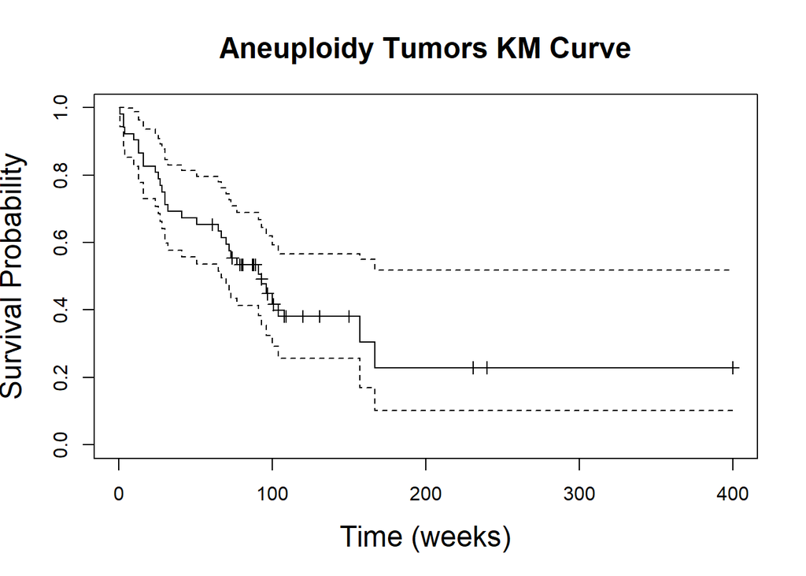

```r
# KM Survivor Function
KM.a = survfit(Surv(time,delta)~1, data = subset(tongue, type==1), conf.type='log')
plot(KM.a, mark.time = TRUE,
     xlab="Time (weeks)", ylab="Survival Probability", main="Aneuploidy Tumors KM Curve",
     cex.lab=1.5, cex.main=1.5)
```

```r
# Estimated 1-year survival rate with 95% CI
surv.a = summary(KM.a,time=52)
surv.a
```

```
## Call: survfit(formula = Surv(time, delta) ~ 1, data = subset(tongue,
##     type == 1), conf.type = "log")
##
##  time n.risk n.event survival std.err lower 95% CI upper 95% CI
##    52     34      18    0.654   0.066        0.537        0.797
```

The 1-year (or 52-week) survival rate for aneuploidy tumors is 0.65 with a 95% confidence interval of 0.54 to 0.8.

**Diploid Tumors**

```r
# View Survival Data
tong.d = tongue[tongue$type == 2,]
Surv(time = tong.d$time, event = tong.d$delta)
```

```
##  [1]   1    3    4    5    5    8   12   13   18   23   26   27   30   42   56
## [16]  62   69  104  104  112  129  181    8+  67+  76+ 104+ 176+ 231+
```

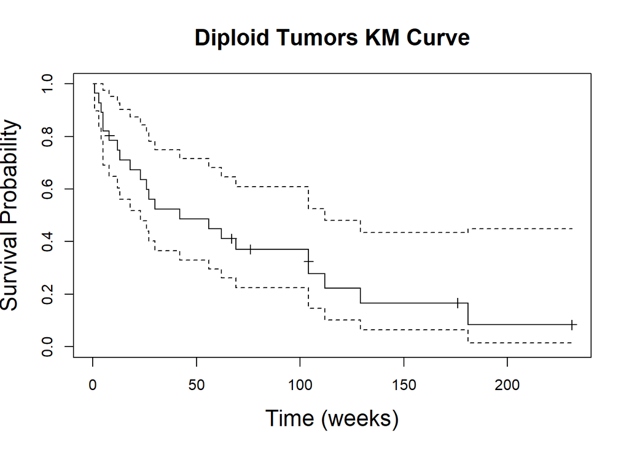

```r
# KM Survivor Function
KM.d = survfit(Surv(time,delta)~1, data = subset(tongue, type==2), conf.type='log')
plot(KM.d, mark.time = TRUE,
     xlab="Time (weeks)", ylab="Survival Probability", main="Diploid Tumors KM Curve",
     cex.lab=1.5, cex.main=1.5)
```

```r
# Estimated 1-year survival rate with 95% CI
surv.d = summary(KM.d,time=52)
surv.d
```

```
## Call: survfit(formula = Surv(time, delta) ~ 1, data = subset(tongue,
##     type == 2), conf.type = "log")
##
##  time n.risk n.event survival std.err lower 95% CI upper 95% CI
##    52     13      14    0.486  0.0961         0.33        0.716
```

The 1-year (or 52-week) survival rate for diploid tumors is 0.49 with a 95% confidence interval of 0.33 to 0.72. Based on this dataset, the 1-year survival rate is higher for aneuploidy tumors, suggesting that there could potentially be better prognosis for those cases.

## **Problem 3**

**For the following data**

$$1, 2, 2, 4+, 5+, 6, 7+, 8+, 9+,
10+$$

**where + denotes a right censored observation. Write out the data table and calculate the following by hand.**

**(a) Find the Kaplan-Meier estimate of the survival function;**

```r
# Pull survival data into a tibble
dat = tibble(
  t.i = c(1, 2, 2, 4, 5, 6, 7, 8, 9, 10),
  delta = c(1, 1, 1, 0, 0, 1, 0, 0, 0, 0)
)

# Check that data has been entered correctly
Surv(time = dat$t.i, event = dat$delta)
```

```
##  [1]  1   2   2   4+  5+  6   7+  8+  9+ 10+
```

Next we manipulate the tibble above to generate the Kaplan-Meier.

```r
km.table = dat |>
  group_by(t.i) |>
  summarize(d.i = sum(delta), .groups = "drop") |> # deaths for each t.i
  mutate(n.i = sapply(t.i, function(t) sum(dat$t.i >= t))) |> # number at risk
  filter(d.i > 0) |> # filter only death times
  mutate(
    csp = 1 - (d.i / n.i), # conditional survival probability at t.i
    survival = cumprod(1 - (d.i / n.i))) # cumulative product of csp

km.table |>
  knitr::kable(digits = 3)
```

| t.i | d.i | n.i | csp | survival |
| --- | --- | --- | --- | --- |
| 1 | 1 | 10 | 0.900 | 0.90 |
| 2 | 2 | 9 | 0.778 | 0.70 |
| 6 | 1 | 5 | 0.800 | 0.56 |

If we were to calculate this by hand:

$$\hat{S}(t) = \prod^k_{i=1} \left(1 -
\frac{d_i}{n_i}\right), \quad t_k \leq t < t_{k+1}$$

**At time $t_1 = 1$:**

- $t_i = 1$
- $d_i = 1$
- $n_i = 10$

Conditional survival probability at $t_1$: **$0.9$**

$$1 - \left(\frac{d_i}{n_i}\right) = 1 -
\frac{1}{10} = 0.9$$

Survival at $t_1$: **$0.9$**

$$\hat{S}(1) = 0.9$$

**At time $t_2 = 2$:**

- $t_i = 2$
- $d_i = 2$
- $n_i = 9$

Conditional survival probability at $t_2$: **$0.778$**

$$1 - \left(\frac{d_i}{n_i}\right) = 1 -
\frac{2}{9} = 0.7778$$

Survival at $t_2$: **$0.7$**

$$\hat{S}(2) = 0.9 \cdot 0.7778 =
0.7$$

**At time $t_3 = 6$:**

- $t_i = 6$
- $d_i = 1$
- $n_i = 5$

Conditional survival probability at $t_3$: **$0.8$**

$$1 - \left(\frac{d_i}{n_i}\right) = 1 -
\frac{1}{5} = 0.8$$

Survival at $t_3$: **$0.56$**

$$\hat{S}(6) = 0.9 \cdot 0.7778 \cdot 0.8
= 0.56$$

**Kaplan-Meier Estimator Interpretation:** The estimated probability that an individual survives beyond 6 units of time is 56%.

**(b) Find the Nelson-Aalen estimate of the cumulative hazard function;**

The Nelson-Aalen estimator is:
$$\hat{H}(t) = \sum^k_{t_i\leq t}
\frac{d_i}{n_i}$$
Let’s manipulate the previous data table to find this.

```r
na.table = km.table |>
  select(-c(csp, survival)) |>
  mutate(
    h.t = d.i/n.i,
    cum.h = cumsum(h.t))

na.table |>
  knitr::kable(digits = 3)
```

| t.i | d.i | n.i | h.t | cum.h |
| --- | --- | --- | --- | --- |
| 1 | 1 | 10 | 0.100 | 0.100 |
| 2 | 2 | 9 | 0.222 | 0.322 |
| 6 | 1 | 5 | 0.200 | 0.522 |

If we were to calculate this by hand:

$$\hat{H}(t) = \frac{1}{10} + \frac{2}{9}
+ \frac{1}{5}$$
$$\hat{H}(t) = 0.1 +
0.222 + 0.2$$
$$\hat{H}(t) =
0.522$$

**(c) Find the Fleming-Harrington estimate of the survival function.**

```r
fa.est = na.table |>
  filter(t.i == 6) |>
  mutate(cum.h = -cum.h) |>
  pull(cum.h) |>
  exp()

fa.est
```

```
## [1] 0.5932009
```

If we were to calculate this by hand…

$$S_{FH}(t) =
exp\left(-\tilde{H}(t)\right)$$
$$S_{FH}(t) = exp\left(-0.5222\right)$$
$$S_{FH}(t) = 0.593$$

**Fleming-Harrington Estimator Interpretation:** The estimated probability that an individual survives beyond 6 units of time is approximately 59.3%.